# Survival Analysis

ChatGPT 4o

2025-01-21

## 2 原理

生存分析的核心是分析和建模时间到事件的数据，通常称为生存时间。该方法的关键特征是其处理“删失数据”（Censored Data）的能力——即在某些情况下，我们并不知道确切的生存时间，但知道事件没有发生或者发生在某个时间段内。

生存分析的主要概念包括：

- **生存函数（Survival Function, S(t)）**：表示个体在时间$t$之后仍然存活的概率。
- **风险函数（Hazard Function, h(t)）**：表示在时间$t$时刻个体经历事件的瞬时风险。

常用的生存分析方法包括：

- **Kaplan-Meier估计**：用于估计生存函数，绘制生存曲线。
- **Cox比例风险模型**：用于评估多个协变量对生存时间的影响，不需要假设生存时间的分布。

## 3 适用范围

生存分析适用于以下情况：

- **时间到事件数据**：研究感兴趣的事件（如死亡、复发、机器失效）发生所需的时间。
- **删失数据的处理**：适用于存在删失数据的情况，例如部分研究对象未经历感兴趣的事件或研究在特定时间结束时仍然存活。
- **多因素影响**：用于评估多个因素对生存时间的影响，例如治疗方法、患者年龄等。

## 4 应用情境

生存分析在多个领域中都有广泛的应用，例如：

- **医学研究**：用于研究患者的生存时间，比较不同治疗方法的效果。
- **工程学**：用于分析机器的故障时间，评估产品的可靠性。
- **社会科学**：用于分析社会事件的时间，例如婚姻持续时间、失业持续时间等。
- **金融学**：用于分析贷款违约时间、客户流失时间等。

## 5 优缺点

### 优点

- **处理删失数据**：生存分析能够有效处理右删失数据，这在很多实际应用中非常常见。
- **灵活性高**：Cox比例风险模型无需对生存时间的分布做假设，适用性较广。
- **多因素分析**：可以通过多变量模型同时评估多个因素对生存时间的影响。

### 缺点

- **假设依赖性**：Cox比例风险模型依赖比例风险假设，即不同组之间的风险比不随时间变化。如果假设不成立，模型结果可能失效。
- **数据要求高**：生存分析通常需要较长时间的随访和较大的样本量，以确保结果的可靠性。
- **复杂性**：与普通回归分析相比，生存分析的模型构建和结果解释相对复杂。

## 6 在R中的实现及结果解释

在R中，可以使用`survival`包中的`survfit()`函数进行Kaplan-Meier估计，使用`coxph()`函数进行Cox比例风险模型分析。以下是一个生存分析的实现示例：

```r
# 加载必要的包
library(survival)
library(ggplot2)

# 示例数据：生成假设数据
set.seed(123)
data <- data.frame(
  time = rexp(100, rate = 0.1),
  status = rbinom(100, 1, 0.7),
  age = rnorm(100, mean = 60, sd = 10),
  treatment = rep(c("A", "B"), each = 50)
)

# 进行Kaplan-Meier生存曲线估计
km_fit <- survfit(Surv(time, status) ~ treatment, data = data)

# 输出Kaplan-Meier生存曲线结果
summary(km_fit)
```

```
## Call: survfit(formula = Surv(time, status) ~ treatment, data = data)
##
##                 treatment=A
##    time n.risk n.event survival std.err lower 95% CI upper 95% CI
##   0.292     50       1   0.9800  0.0198       0.9420        1.000
##   0.316     49       1   0.9600  0.0277       0.9072        1.000
##   0.318     48       1   0.9400  0.0336       0.8764        1.000
##   0.562     47       1   0.9200  0.0384       0.8478        0.998
##   1.453     46       1   0.9000  0.0424       0.8206        0.987
##   1.883     45       1   0.8800  0.0460       0.7944        0.975
##   2.596     43       1   0.8595  0.0492       0.7683        0.962
##   2.810     42       1   0.8391  0.0521       0.7429        0.948
##   3.165     40       1   0.8181  0.0549       0.7173        0.933
##   3.771     39       1   0.7971  0.0574       0.6923        0.918
##   4.204     38       1   0.7761  0.0596       0.6678        0.902
##   4.802     36       1   0.7546  0.0617       0.6429        0.886
##   5.066     35       1   0.7330  0.0636       0.6184        0.869
##   5.887     32       1   0.7101  0.0656       0.5925        0.851
##   5.909     31       1   0.6872  0.0674       0.5671        0.833
##   6.293     29       1   0.6635  0.0691       0.5410        0.814
##   7.907     28       1   0.6398  0.0706       0.5155        0.794
##   8.457     25       1   0.6142  0.0722       0.4878        0.773
##   8.498     24       1   0.5886  0.0736       0.4607        0.752
##   9.659     23       1   0.5630  0.0747       0.4341        0.730
##  11.003     21       1   0.5362  0.0758       0.4064        0.707
##  11.293     20       1   0.5094  0.0766       0.3793        0.684
##  11.685     19       1   0.4826  0.0771       0.3528        0.660
##  12.290     18       1   0.4558  0.0774       0.3268        0.636
##  12.546     17       1   0.4290  0.0773       0.3013        0.611
##  13.291     15       1   0.4004  0.0773       0.2743        0.584
##  13.480     14       1   0.3718  0.0769       0.2479        0.558
##  14.967     11       1   0.3380  0.0770       0.2163        0.528
##  15.707      9       1   0.3004  0.0770       0.1818        0.497
##  16.059      8       1   0.2629  0.0760       0.1492        0.463
##  21.678      7       1   0.2253  0.0738       0.1185        0.428
##  22.483      6       1   0.1878  0.0704       0.0900        0.392
##  27.253      4       1   0.1408  0.0667       0.0557        0.356
##  40.410      2       1   0.0704  0.0599       0.0133        0.373
##  72.110      1       1   0.0000     NaN           NA           NA
##
```

[output cut: 23 more lines]

```
##  10.279     22       1   0.4992  0.0762       0.3702        0.673
##  10.477     21       1   0.4754  0.0762       0.3473        0.651
##  10.672     20       1   0.4516  0.0760       0.3248        0.628
##  11.149     18       1   0.4265  0.0758       0.3011        0.604
##  11.920     17       1   0.4015  0.0754       0.2779        0.580
##  14.395     15       1   0.3747  0.0749       0.2532        0.555
##  15.631     11       1   0.3406  0.0755       0.2206        0.526
##  15.705     10       1   0.3066  0.0752       0.1895        0.496
##  16.199      9       1   0.2725  0.0742       0.1598        0.465
##  16.424      8       1   0.2384  0.0723       0.1316        0.432
##  17.312      7       1   0.2044  0.0695       0.1049        0.398
##  18.569      6       1   0.1703  0.0658       0.0799        0.363
##  18.878      4       1   0.1277  0.0616       0.0497        0.329
##  25.361      3       1   0.0852  0.0538       0.0247        0.294
##  44.987      1       1   0.0000     NaN           NA           NA
```

```r
str(km_fit)
```

```
## List of 17
##  $ n        : int [1:2] 50 50
##  $ time     : num [1:100] 0.292 0.316 0.318 0.562 1.453 ...
##  $ n.risk   : num [1:100] 50 49 48 47 46 45 44 43 42 41 ...
##  $ n.event  : num [1:100] 1 1 1 1 1 1 0 1 1 0 ...
##  $ n.censor : num [1:100] 0 0 0 0 0 0 1 0 0 1 ...
##  $ surv     : num [1:100] 0.98 0.96 0.94 0.92 0.9 ...
##  $ std.err  : num [1:100] 0.0202 0.0289 0.0357 0.0417 0.0471 ...
##  $ cumhaz   : num [1:100] 0.02 0.0404 0.0612 0.0825 0.1043 ...
##  $ std.chaz : num [1:100] 0.02 0.0286 0.0354 0.0413 0.0466 ...
##  $ strata   : Named int [1:2] 50 50
##   ..- attr(*, "names")= chr [1:2] "treatment=A" "treatment=B"
##  $ type     : chr "right"
##  $ logse    : logi TRUE
##  $ conf.int : num 0.95
##  $ conf.type: chr "log"
##  $ lower    : num [1:100] 0.942 0.907 0.876 0.848 0.821 ...
##  $ upper    : num [1:100] 1 1 1 0.998 0.987 ...
##  $ call     : language survfit(formula = Surv(time, status) ~ treatment, data = data)
##  - attr(*, "class")= chr "survfit"
```

```r
# 进行Cox比例风险模型分析
cox_model <- coxph(Surv(time, status) ~ age + treatment, data = data)

# 输出Cox模型结果
summary(cox_model)
```

```
## Call:
## coxph(formula = Surv(time, status) ~ age + treatment, data = data)
##
##   n= 100, number of events= 71
##
##                coef exp(coef) se(coef)     z Pr(>|z|)
## age        0.007862  1.007893 0.011392 0.690    0.490
## treatmentB 0.168944  1.184053 0.243165 0.695    0.487
##
##            exp(coef) exp(-coef) lower .95 upper .95
## age            1.008     0.9922    0.9856     1.031
## treatmentB     1.184     0.8446    0.7352     1.907
##
## Concordance= 0.504  (se = 0.039 )
## Likelihood ratio test= 0.84  on 2 df,   p=0.7
## Wald test            = 0.84  on 2 df,   p=0.7
## Score (logrank) test = 0.84  on 2 df,   p=0.7
```

```r
str(cox_model)
```

[output not shown]

### 结果解释

- **Kaplan-Meier估计**：`survfit()`的结果可以用于绘制不同治疗组的生存曲线，通过比较不同组的生存曲线，可以直观地观察不同治疗方案的效果。
- **Cox比例风险模型**：`coxph()`的输出中包含每个协变量的风险比（Hazard Ratio, HR）、标准误差和p值。风险比表示协变量对事件发生速率的影响。例如，如果年龄的风险比大于1，则表明年龄越大，事件（如死亡）的发生速率越高。

### 结果的可视化

可以使用`ggsurvplot()`函数对Kaplan-Meier生存曲线进行可视化，以展示不同组的生存情况。

```r
# 加载必要的包
# 安装并加载survminer包（如果尚未安装）
if (!requireNamespace("survminer", quietly = TRUE)) {
  install.packages("survminer")
}
library(survminer)
```

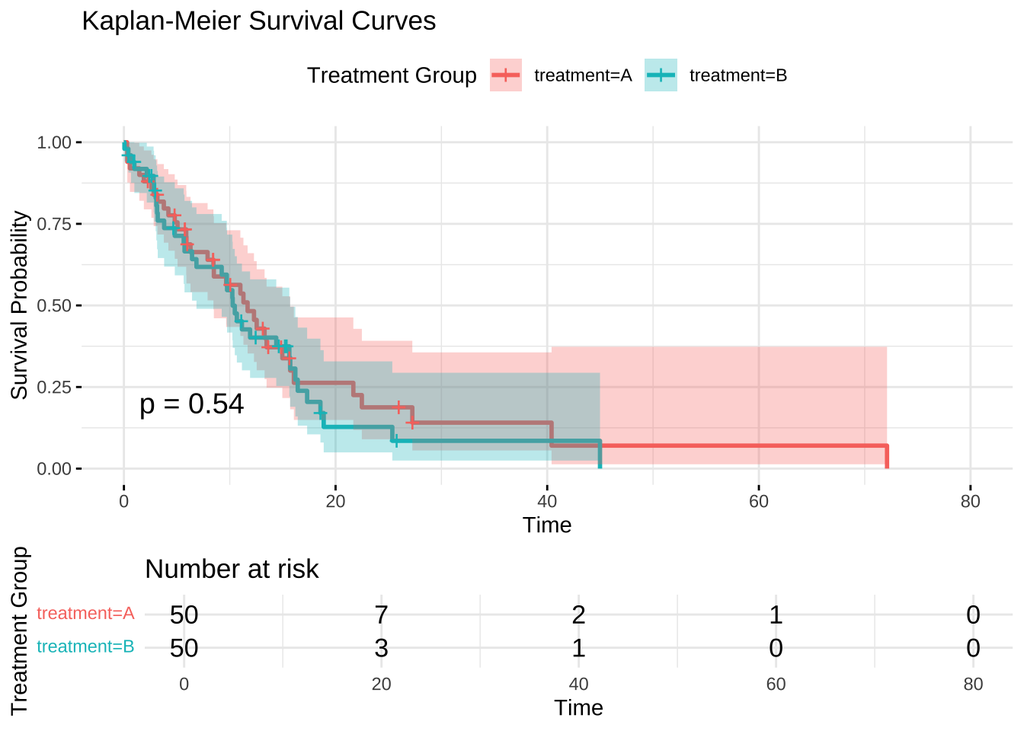

```r
# 绘制Kaplan-Meier生存曲线
ggsurvplot(km_fit, data = data,
           pval = TRUE,
           conf.int = TRUE,
           risk.table = TRUE,
           ggtheme = theme_minimal(),
           title = "Kaplan-Meier Survival Curves",
           xlab = "Time",
           ylab = "Survival Probability",
           legend.title = "Treatment Group")
```

上述代码将生成Kaplan-Meier生存曲线，展示不同治疗组的生存概率随时间的变化情况。不同颜色的曲线表示不同治疗组的生存情况，便于直观比较组间差异。

## 7 小结

- 生存分析是一种用于分析时间到事件数据的统计方法，能够处理删失数据，广泛应用于医学、工程和社会科学等领域。
- 适用于研究生存时间或事件发生时间，并能有效地评估多个因素对生存时间的影响。
- 具有处理删失数据、多因素分析等优点，但依赖于比例风险假设，数据要求较高。
- 可以通过R中的`survfit()`和`coxph()`函数实现生存分析，并结合可视化工具直观展示生存曲线和模型结果。
- 生存分析在理解时间到事件的动态变化以及多因素的交互作用方面具有重要作用，是医学和其他领域中的重要工具。